# Project: Drivers of nutrient retention in Western US lakes

Carolina Barbosa

2022-08-25

## Goal of this project

Building a prediction model based on some covariates (e.g. ice dynamics, watershed characteristics, trophic state) of nutrient retention in Western lakes and predict trends based on climate change scenarios using machine learning approaches.

Questions: How strong are nutrient internal cycles in the Western lakes? Is the dry weather a driver of nutrient retention? Can climate change alter that?

Datasets: We will use available temporal and spatial datasets (e.g. LAGOS, EPA, HydroLAKES, EDI and others)

At first, I have filtered and compared data of US Western lakes from LAGOS-LOCUS, LAGOS-GEO, EPA-NLA2012 and Wu et al.(2022).

## Checking nutrient retention data

I have decided to filter only nutrient retention data from Wu et al (2022) at first.

```r
wu_epa_nla_LAGOS_locus_geo_2 <- wu_epa_nla_LAGOS_locus_geo_2 %>%
  group_by(lagoslakeid, lake_lat_decdeg, lake_lon_decdeg, P_DE, P_EN, N_DE, N_EN) %>%
  mutate(lakes_en_de_ratioP = (P_EN/P_DE), lakes_en_de_ratioN = (N_EN/N_DE))%>%
  summarize(RetainP_lakes= lakes_en_de_ratioP<1,RetainN_lakes= lakes_en_de_ratioN<1 )

N_retain_lakes <- wu_epa_nla_LAGOS_locus_geo_2 %>%
  filter(RetainN_lakes=="TRUE") %>%
  summarize(lagoslakeid)

P_retain_lakes <- wu_epa_nla_LAGOS_locus_geo_2 %>%
  filter(RetainP_lakes=="TRUE") %>%
  summarize(lagoslakeid)
```

Let’s check some plots of Western US lakes with N and P retention.

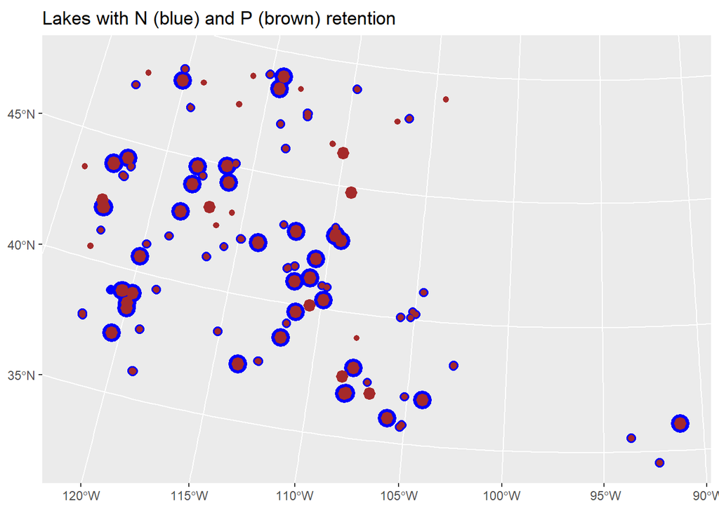

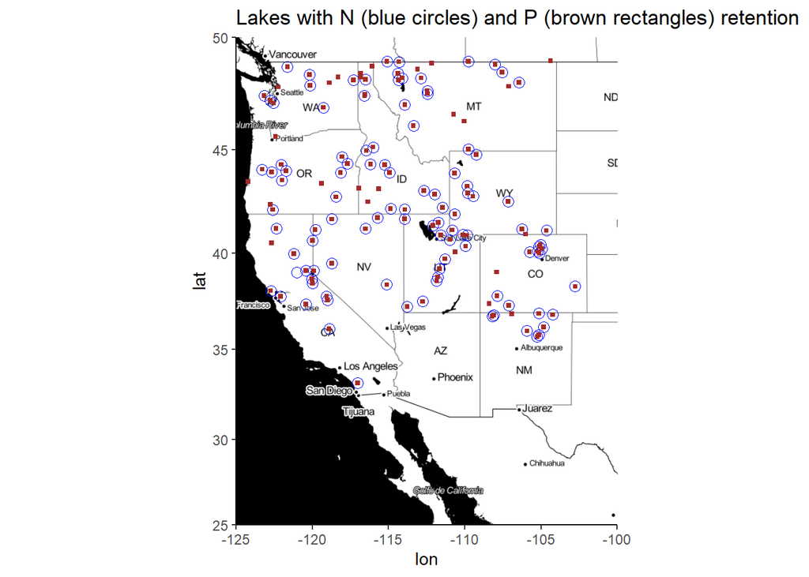

Why some lakes retain N and don’t retain P and vice versa? Let’s see those.

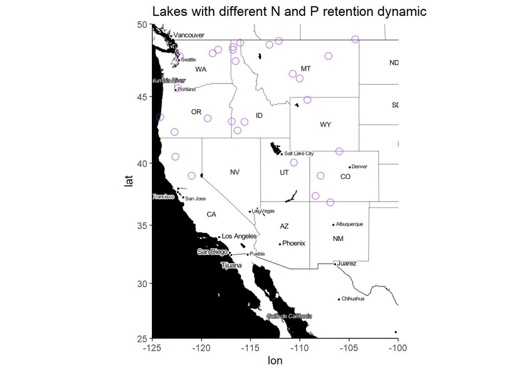

Important question: should I investigate the lakes with N and/or P retention? Or should I investigate these lakes with different internal N and P dynamics??

## Looking at some snow data from Lute et al. 2022

Let’s compare the snow duration data averaged between 2000 and 2013 and the location of the lakes

```
## [1] "The file has 2 variables, 2 dimensions and 10 NetCDF attributes"
```

[output not shown]

```
## $names
## [1] "lat" "lon"
```

```
## $hasatt
## [1] TRUE
##
## $value
## [1] -9999
```

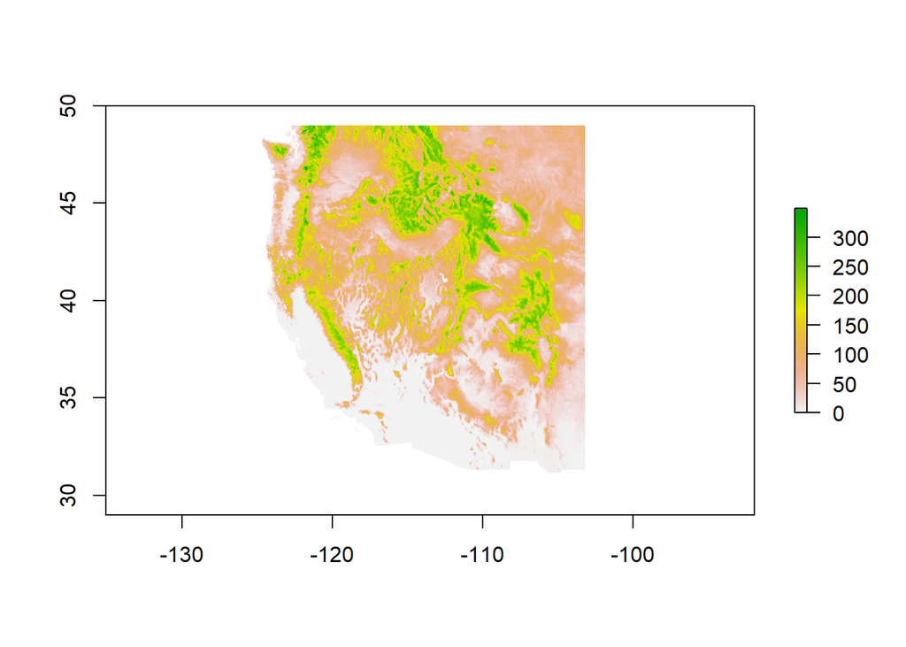

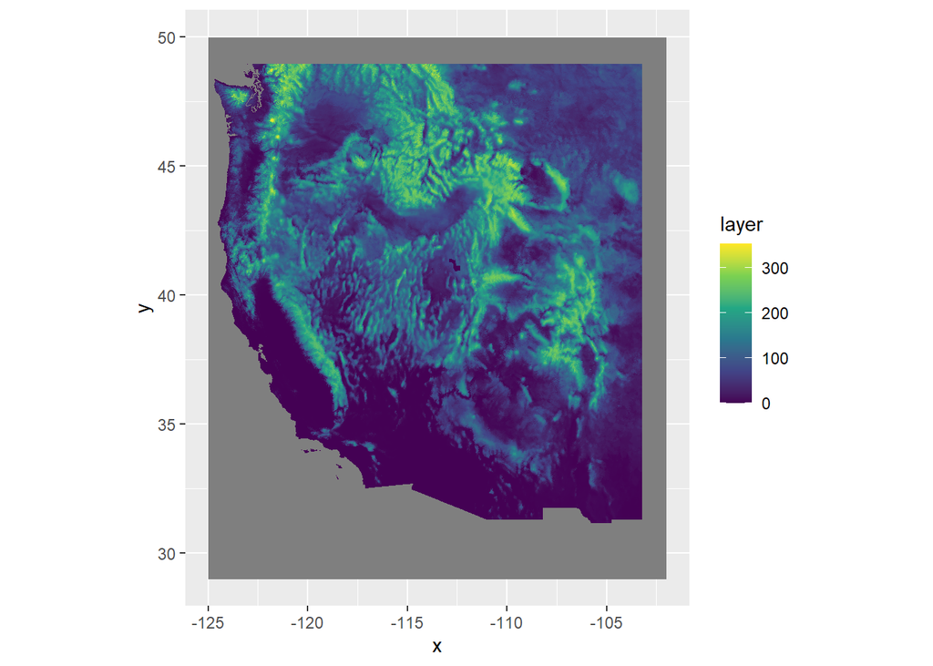

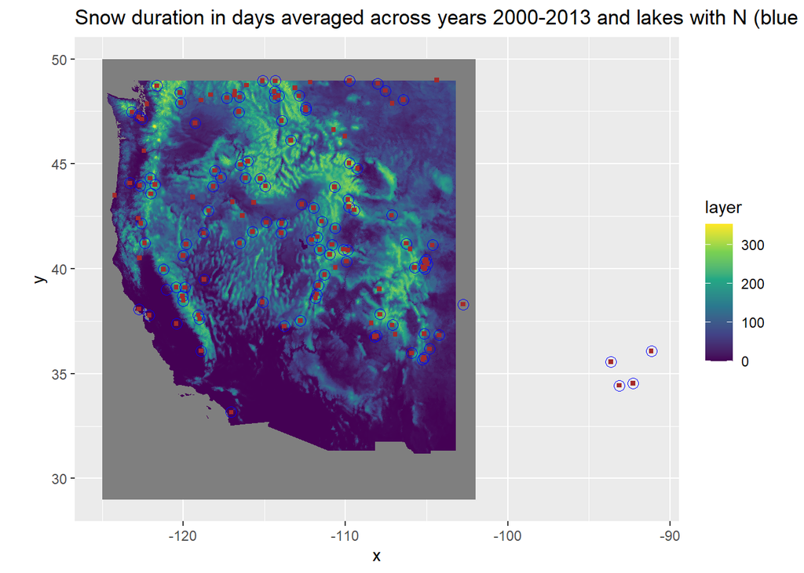